# MR analysis using ADNI and ROSMAP data

Load the data files processed by `ANDI and ROSMAP MR analysis.ipynb`. The probes in the MHC region are removed: MHC region in hg19: MHC_chr = 6, MHC_start = 28477797, MHC_end = 33448354.

```r
library(tidyverse)
xQTL_cis = read_csv("analysis_using_meta_eQTL/xQTLs_expr_metab_prot.csv")
xQTL_cis = xQTL_cis[!is.na(xQTL_cis$pvalue_GWAS), ]
dim(xQTL_cis)
```

```
## [1] 56815    26
```

```r
# verify that the MHC region has already been removed in the preprocessing steps
# they have been removed because the data is from the eQTL meta analysis from ROS/MAP and CMC
xQTL_cis = xQTL_cis[(xQTL_cis$chromosome != 6) | (xQTL_cis$snpLocation < 28477797) | (xQTL_cis$snpLocation > 33448354), ]
dim(xQTL_cis)
```

```
## [1] 56815    26
```

```r
snpid_groups = split(xQTL_cis$snpid, xQTL_cis$geneSymbol)

# There is only one gene with more than 1000 genes. Due to the constraint of LDlinkR, we only
# use the SNPs with the top 1000 smallest GWAS beta SEs.
head(sort(sapply(snpid_groups, length), decreasing=TRUE))
```

```
##  FHIT ASIC2 PRKG1 PLCB1 PDE4D  DGKB
##  1226   848   749   558   538   460
```

```r
snpid_groups[["FHIT"]] = xQTL_cis[xQTL_cis$geneSymbol == "FHIT", ]$snpid[
rank(-abs(xQTL_cis$beta_GWAS / xQTL_cis$statistic_GWAS)[xQTL_cis$geneSymbol == "FHIT"]) <= 1000]
head(sort(sapply(snpid_groups, length), decreasing=TRUE))
```

```
##  FHIT ASIC2 PRKG1 PLCB1 PDE4D  DGKB
##  1000   848   749   558   538   460
```

```r
LDmatrix_list = NULL
library(LDlinkR)
library(pbapply)
ldmatrix_file = "analysis_using_meta_eQTL/LDmatrix_expr_metab_prot.rds"
if (!file.exists(ldmatrix_file)) {
  Sys.setenv(LDLINK_TOKEN = "ae178767d608")
  LDmatrix_list = pblapply(snpid_groups,
                         function(x) {
                           if (length(x) == 1) return(NA)
                           else {
                             LD = LDmatrix(x, "CEU", "r2",
                                  token = Sys.getenv("LDLINK_TOKEN"))
                             if (ncol(LD) == nrow(LD) + 1) LD = LD[, -1]
                             LD_is_not_NA_SNPs = !is.na(LD[, 1])
                             LD = LD[LD_is_not_NA_SNPs, LD_is_not_NA_SNPs]
                             rownames(LD) = colnames(LD)
                             LD
                           }
                          })
  saveRDS(LDmatrix_list, file=ldmatrix_file)
} else {
  LDmatrix_list = readRDS(ldmatrix_file)
}
```

```r
source("~/Downloads/simulation_SMR_multi/SMR_functions.R")  # get_p_values_from_summary()
genes = unique(xQTL_cis$geneSymbol)
result_list = pblapply(genes, function (gene) {
  snps = intersect(xQTL_cis$snpid[xQTL_cis$geneSymbol == gene], colnames(LDmatrix_list[[gene]]))
  row_indices =  which(xQTL_cis$geneSymbol == gene & xQTL_cis$snpid %in% snps)

  zx_est = na.omit(t(xQTL_cis[row_indices, c("beta_expr", "beta_prot", "beta_metab")]))
  zx_se = na.omit(zx_est / t(xQTL_cis[row_indices, c("statistic_expr", "statistic_prot", "statistic_metab")]))
  zy_est = xQTL_cis[row_indices, "beta_GWAS"][[1]]
  zy_se = (zy_est / xQTL_cis[row_indices, "statistic_GWAS"])[[1]]

  get_p_values_from_summary(zx_est, zx_se, zy_est, zy_se,
                            r2 = LDmatrix_list[[gene]][snps, snps],
                            bp = xQTL_cis$snpLocation[row_indices],
                            max_r2 = 0.2, min_dist_bp = 1e5)
})
result_matrix = do.call("rbind", result_list)
rownames(result_matrix) = genes
```

```r
# Agora (nominated targets) https://agora.ampadportal.org/genes
agora_gene_list = read_csv("gene_list/agora_gene_list.csv")
length(agora_gene_list$hgnc_symbol)
```

```
## [1] 584
```

```r
genes = unique(xQTL_cis$geneSymbol)
length(agora_gene_list$hgnc_symbol)
```

```
## [1] 584
```

```r
length(genes)
```

```
## [1] 540
```

```r
length(intersect(agora_gene_list$hgnc_symbol, genes))
```

```
## [1] 41
```

```r
result_matrix_in_agora = result_matrix[intersect(agora_gene_list$hgnc_symbol, genes), ]
result_matrix_in_agora
```

```
##          Multivariable MultivariableLD IVW_Cauchy_cauchy   IVW_HMP
## PDHB                NA              NA         0.6156708 0.6542237
## PRDX6               NA              NA         0.4580926 0.5783572
## ATP1B1              NA              NA         0.2745699 0.4032682
## CS                  NA              NA         1.0000000 0.7998742
## NNT                 NA              NA         0.4473883 0.5868032
## PAFAH1B3            NA              NA         0.5200882 0.6214406
## AADAT               NA              NA         0.6572673 0.7002505
## ABCA7               NA              NA         0.2868414 0.3457960
## ACO2                NA              NA         0.4248386 0.5010179
## ACSL1               NA              NA         0.7385395 0.7358487
## AK1                 NA              NA         0.8459105 0.6279118
## AK4                 NA              NA         0.8454416 0.7526092
## AKT1                NA              NA         0.7505645 0.6431134
## ATP1A3              NA              NA         0.8423673 0.5549773
## BDH2                NA              NA         0.6722969 0.6758751
## CYP27A1             NA              NA         0.9456977 0.6474649
## DBT                 NA              NA         0.2962975 0.4350263
## DLD                 NA              NA         0.6422577 0.6761270
## GAD1                NA              NA         0.5693261 0.6493117
## GDA                 NA              NA         0.2745487 0.4079614
## GJA1                NA              NA         0.7632605 0.7289823
## GMPR                NA              NA         0.6321453 0.6988128
## GSTK1               NA              NA         0.4011004 0.5178374
## IDH2                NA              NA         0.8366188 0.6576001
## MAPK1               NA              NA         0.3647083 0.5057598
## MDH1                NA              NA         0.5727436 0.6487087
## MDH2                NA              NA         0.4016908 0.5419120
## MGST3               NA              NA         0.8692784 0.7631019
## NMNAT2              NA              NA         0.6900799 0.7148249
## PHGDH               NA              NA         0.9164934 0.5637537
## PIK3CA              NA              NA         0.8803102 0.7442944
## PIK3CB              NA              NA         0.5523394 0.6606927
## PLCB1        0.2040759       0.2569239         0.8395303 0.7713933
## PSPH                NA              NA         0.3436817 0.4674962
## RPS6KA2      0.2027996       0.1567869         0.5520627 0.5052627
## RRM1                NA              NA         0.4590825 0.5924485
## RRM2B               NA              NA         0.5925222 0.5359622
## SGPL1               NA              NA         0.6271750 0.6757246
## SGPP1               NA              NA         0.9609352 0.7045728
```

[output cut: 365 more lines]

```
## MDH2                   0.6719965243               0.6579055240
## MGST3                  0.7522484470               0.7363235722
## NMNAT2                 0.9268827045               0.9143514713
## PHGDH                  0.8847292844               0.8698517685
## PIK3CA                 0.2317694841               0.2365364759
## PIK3CB                 0.6541565096               0.6406264269
## PLCB1                  0.7945070357               0.7782135296
## PSPH                   0.2156711579               0.2209843663
## RPS6KA2                0.0659209517               0.0727373698
## RRM1                   0.7012510348               0.6863490519
## RRM2B                  0.1918142453               0.1978506704
## SGPL1                  0.6823927717               0.6679972451
## SGPP1                  0.7795636355               0.7633426180
## SRR                    0.0132841145               0.0164254691
## TUBB3                  0.0857998573               0.0930269198
```

```r
# chromosome length -- See https://msmith.de/2019/06/05/chrom-lengths-in-bioc.html
library(GenomicFeatures)
```

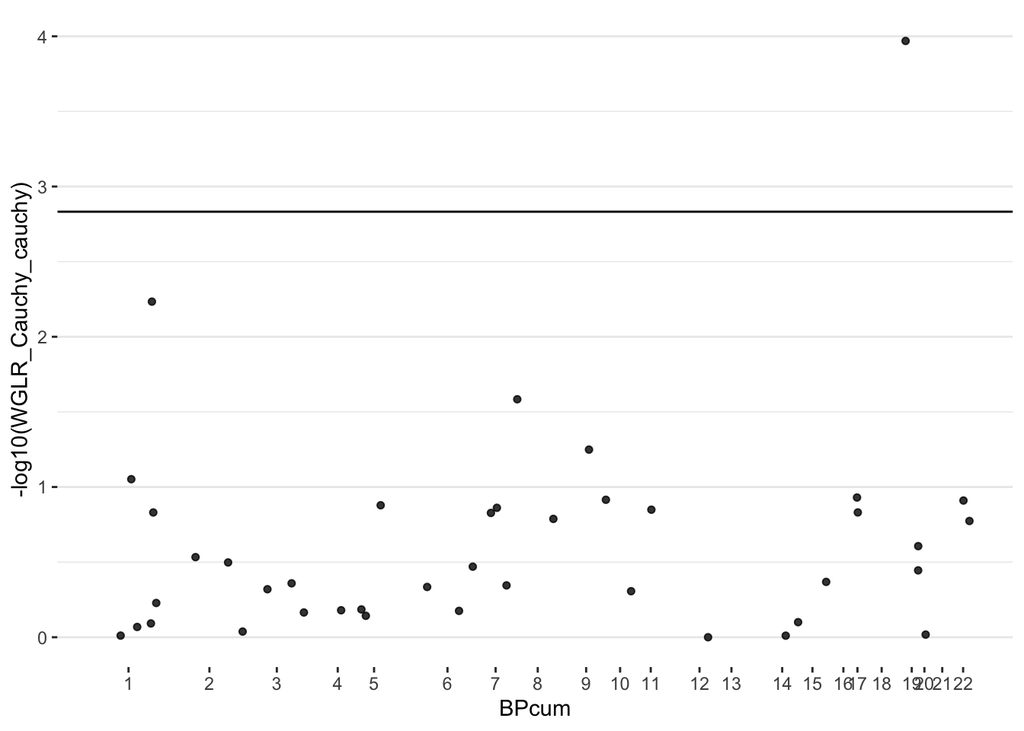

```r
chrom_length_file = "cis/chrom_length_grch37_ensembl.csv"
if (!file.exists(chrom_length_file)) {
  chrom_length = getChromInfoFromBiomart(biomart="ENSEMBL_MART_ENSEMBL",
                        host="grch37.ensembl.org",
                        dataset="hsapiens_gene_ensembl") %>%
    dplyr::arrange(chrom)
  write.csv(chrom_length, file = chrom_length_file)
} else {
  chrom_length = read.csv(file = chrom_length_file)
}

genes = colnames(result_matrix_in_agora)

# Cauchy
# See https://www.r-graph-gallery.com/101_Manhattan_plot.html
library(qqman)
results_with_coords = merge(xQTL_cis, result_matrix_in_agora, by.x = "geneSymbol", by.y = 0, all.x = FALSE, all.y = TRUE)
results_with_coords = results_with_coords[!duplicated(results_with_coords$geneSymbol), ]
results_with_coords = merge(results_with_coords, chrom_length, by.x = "chromosome", by.y = "chrom", all.x = TRUE, all.y = FALSE)
results_with_coords = results_with_coords[!duplicated(results_with_coords$geneSymbol), ]

results_with_coords$chr = results_with_coords$chromosome
results_with_coords$BP = results_with_coords$snpLocation

# not combined
results_with_coords$SMR_expression = results_with_coords$WGLR_OneModality1
results_with_coords$SMR_protein = results_with_coords$WGLR_OneModality2
results_with_coords$SMR_metabolite = results_with_coords$WGLR_OneModality3
results_with_coords_long = pivot_longer(results_with_coords, cols=c("SMR_expression", "SMR_protein", "SMR_metabolite"), names_to = "modality", values_to = "pval_SMR")

results_with_coords_for_plot = results_with_coords
results_with_coords_long_for_plot = results_with_coords_long

for (chr in 1:22) {
  # set -log10(p) to -1 to hide the boundaries:
  results_with_coords_for_plot = results_with_coords_for_plot %>% add_row(chr = chr, BP = 1, WGLR_Cauchy_cauchy = 10)
  results_with_coords_for_plot = results_with_coords_for_plot %>% add_row(chr = chr, BP = chrom_length$length[chrom_length$chrom == chr], WGLR_Cauchy_cauchy = 10)
    results_with_coords_long_for_plot = results_with_coords_long_for_plot %>% add_row(chr = chr, BP = 1, WGLR_Cauchy_cauchy = 10)
  results_with_coords_long_for_plot = results_with_coords_long_for_plot %>% add_row(chr = chr, BP = chrom_length$length[chrom_length$chrom == chr], WGLR_Cauchy_cauchy = 10)
}

# TODO: technically the coords are from SNPs -- need to change to genes if we really want to be precise (at most 1 M bp apart)
# manhattan(results_with_coords_for_plot, chr="chr", bp="BP", snp="Symbol", p="pval_SMR_topSNP_Cauchy_cauchy",
#           annotatePval = 0.1,
#           main = "SMR P-values after Cauchy combination",
#           suggestiveline = -log10(0.05 / nrow(results)) - 2,
#           genomewideline = -log10(0.05 / nrow(results)),
#           ylim = c(0, 4))

# using ggplot2 instead; see  https://www.r-graph-gallery.com/101_Manhattan_plot.html
results_with_coords_for_ggplot = results_with_coords
for (chr in 1:22) {
  # set -log10(p) to -1 to hide the boundaries:
  results_with_coords_for_ggplot = results_with_coords_for_ggplot %>% add_row(chr = chr, BP = 0, WGLR_Cauchy_cauchy = NA)
}
don = chrom_length %>% as_tibble() %>%
  # Compute chromosome size
  filter(chrom %in% 1:22) %>%
  dplyr::mutate(chr = as.numeric(chrom)) %>%
  arrange(chr) %>%
  # Calculate cumulative position of each chromosome
  mutate(tot=cumsum(as.numeric(length))-length) %>%
  dplyr::select(chr, tot) %>%
  # Add this info to the initial dataset
  left_join(results_with_coords_for_ggplot, ., by=c("chr"="chr")) %>%
  # Add a cumulative position of each SNP
  arrange(chr, BP) %>%
  mutate(BPcum=BP+tot)

axisdf = don %>% group_by(chr) %>% summarize(center=( max(BPcum) + min(BPcum) ) / 2 )
ggplot(don, aes(x=BPcum, y=-log10(WGLR_Cauchy_cauchy))) +
    # Show all points (color according to chr)
    #geom_point( aes(color=as.factor(chr)), alpha=0.8, size=1.3) +
    #scale_color_manual(values = rep(c("grey", "skyblue"), 22 )) +
    # Show all points (color according to omic modality)
    geom_point(alpha=0.8, size=1.3) +
    geom_hline(yintercept=-log10(0.05/length(genes))) +
    # custom X axis:
    scale_x_continuous( label = axisdf$chr, breaks= axisdf$center ) +
    #scale_y_continuous(expand = c(0, 0), limits = c(0, 4)) +     # remove space between plot area and x axis
    # Custom the theme:
    theme_bw() +
    theme(
      legend.position="none",
      panel.border = element_blank(),
      panel.grid.major.x = element_blank(),
      panel.grid.minor.x = element_blank()
    )
```

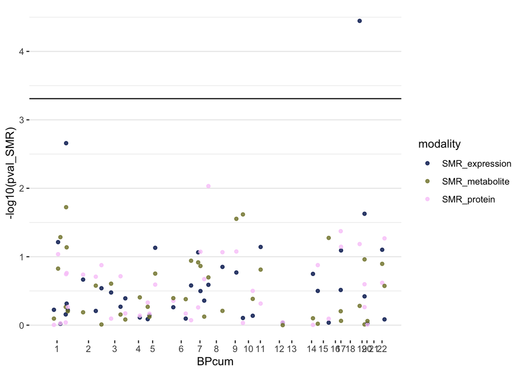

```r
# TODO: technically the coords are from SNPs -- need to change to genes
# TODO: change the color of point to reflect methylation, expression, metabolomics, etc.
# manhattan(results_with_coords_long_for_plot, chr="chr", bp="BP", snp="Symbol", p="pval_SMR",
#           annotatePval = 0.1,
#           main = "SMR P-values before combination",
#           suggestiveline = -log10(0.05 / nrow(results) / 3) - 2,
#           genomewideline = -log10(0.05 / nrow(results) / 3),
#           ylim = c(0, 4))



# using ggplot2 instead; see  https://www.r-graph-gallery.com/101_Manhattan_plot.html
results_with_coords_long_for_ggplot = results_with_coords_long
for (chr in 1:22) {
  # set -log10(p) to -1 to hide the boundaries:
  results_with_coords_long_for_ggplot = results_with_coords_long_for_ggplot %>% add_row(chr = chr, BP = 0, pval_SMR = NA)
}
library(scico)
don = chrom_length %>% as_tibble() %>%
  # Compute chromosome size
  filter(chrom %in% 1:22) %>%
  dplyr::mutate(chr = as.numeric(chrom)) %>%
  arrange(chr) %>%
  # Calculate cumulative position of each chromosome
  mutate(tot=cumsum(as.numeric(length))-length) %>%
  dplyr::select(chr, tot) %>%
  # Add this info to the initial dataset
  left_join(results_with_coords_long_for_ggplot, ., by=c("chr"="chr")) %>%
  # Add a cumulative position of each SNP
  arrange(chr, BP) %>%
  mutate(BPcum=BP+tot)

axisdf = don %>% group_by(chr) %>% summarize(center=( max(BPcum) + min(BPcum) ) / 2 )
ggplot(don, aes(x=BPcum, y=-log10(pval_SMR))) +
    # Show all points (color according to chr)
    #geom_point( aes(color=as.factor(chr)), alpha=0.8, size=1.3) +
    #scale_color_manual(values = rep(c("grey", "skyblue"), 22 )) +
    # Show all points (color according to omic modality)
    geom_point( aes(color=modality), alpha=0.8, size=1.3) +
    scale_color_scico_d(na.translate=FALSE) +
    geom_hline(yintercept=-log10(0.05/length(genes)/3)) +
    # custom X axis:
    scale_x_continuous( label = axisdf$chr, breaks= axisdf$center ) +
    #scale_y_continuous(expand = c(0, 0), limits = c(0, 4)) +     # remove space between plot area and x axis
    # Custom the theme:
    theme_bw() +
    theme(
      #legend.position="none",
      panel.border = element_blank(),
      panel.grid.major.x = element_blank(),
      panel.grid.minor.x = element_blank()
    )
```

```r
# show top combined p-values
results_with_coords %>% as_tibble() %>%
  arrange(WGLR_Cauchy_cauchy) %>%
  dplyr::select(geneSymbol, WGLR_Cauchy_cauchy)
```

```
## # A tibble: 41 x 2
##    geneSymbol WGLR_Cauchy_cauchy
##    <chr>                   <dbl>
##  1 ABCA7                0.000107
##  2 ATP1B1               0.00584
##  3 GSTK1                0.0261
##  4 GDA                  0.0564
##  5 DBT                  0.0887
##  6 TUBB3                0.117
##  7 AK1                  0.122
##  8 MAPK1                0.123
##  9 NNT                  0.132
## 10 MDH2                 0.138
## # … with 31 more rows
```

```r
#  show p-values before combination
results_with_coords_long %>% as_tibble() %>%
  arrange(pval_SMR) %>%
  dplyr::select(geneSymbol, pval_SMR, modality) %>%
  mutate(pval_SMR_adjusted_for_3_modalties = pval_SMR * 3)
```

```
## # A tibble: 123 x 4
##    geneSymbol  pval_SMR modality       pval_SMR_adjusted_for_3_modalties
##    <chr>          <dbl> <chr>                                      <dbl>
##  1 ABCA7      0.0000358 SMR_expression                          0.000107
##  2 ATP1B1     0.00219   SMR_expression                          0.00658
##  3 GSTK1      0.00929   SMR_protein                             0.0279
##  4 ATP1B1     0.0189    SMR_metabolite                          0.0567
##  5 ATP1A3     0.0236    SMR_expression                          0.0707
##  6 AK1        0.0241    SMR_metabolite                          0.0723
##  7 GDA        0.0279    SMR_metabolite                          0.0838
##  8 TUBB3      0.0423    SMR_protein                             0.127
##  9 PHGDH      0.0518    SMR_metabolite                          0.155
## 10 IDH2       0.0531    SMR_metabolite                          0.159
## # … with 113 more rows
```

We need to calculate `zx_est`, `zx_se`, `zy_est`, and `zy_se` for each modality.

Perform LD clumping so that the minimum distance between SNPs is 100 kb.

For each gene, we calculate the MR p-values using a list of methods.

After LD clumping, there is usually only one SNP associated with each gene. This will render the multivariable approach and the methods that usually require multiple SNPs (IVW, WGLR, and GSMR) not practical in most circumstances.

Now we explain our argument for the integrative analysis using multiple modalities. The approaches we need to compare in the real data analysis are non-integrative approaches and integrative approaches. Due to the fact that MinP not being able to control type I error when using summary data, and correlation between estimates for each modality not readily available for Fisher combination method with correction, the integrative approach would mainly refer to Cauchy combination method.

For example, in gene DNMT3A, the methylQTL p-value is 0.0238 and the metabQTL p-value is 0.0523. After using Cauchy combination test, the combined p-value is 0.0328. We can argue that using combined p-values will allow us consider one p-value for a gene, which involves half the number of experiments as opposed to considering all the combination of genes and modalities, thereby offering an advantage when conducting multiple comparisons using the Bonferroni adjustment.

We still need to get more eQTL and methylQTL p-values that can span multiple modalities for a gene.